# Trabajo Final

# Introducción

El nivel socioeconómico se ha asociado estrechamente con el comportamiento humano; en este contexto, problemas de salud mental como la depresión, la ansiedad y el estrés han sido ampliamente investigados en el ámbito de la psicología.

El objetivo de este estudio es explorar la relación entre el tramo de ingreso, la depresión, ansiedad y estrés, para esto **hipotesizamos** que un mayor ingreso económico tendrá un efecto positivo en dichos parametros de salud mental.

# Métodos

## Preparación de los datos

Para esta etapa, se utilizaron 30 “monkeys”, es decir, agentes automatizados diseñados para simular respuestas de manera realista. Gracias a ellos, fue posible generar una base de datos sintética, controlada y reproducible, que permitió preparar el camino para los análisis posteriores.

# Análisis

Se realizaron regresiones lineales con el objetivo de explorar la relación entre el tramo de ingreso y los niveles de salud mental, evaluados mediante las subescalas de estrés, ansiedad y depresión del cuestionario DASS-21. Cada dimensión fue analizada por separado para identificar posibles asociaciones con el nivel de ingreso reportado.

### Tabla 1. Datos descriptivos entre dominios del DASS-21 y tramos de ingreso

[output not shown]

<sup>1</sup> Mean SD

### Tabla 2. Modelos de regresión lineal entre tramo de ingreso y dominios de salud mental (DASS-21)

| **Characteristic** | Estrés **Beta** | Estrés **95% CI** | Estrés **p-value** | Ansiedad **Beta** | Ansiedad **95% CI** | Ansiedad **p-value** | Depresión **Beta** | Depresión **95% CI** | Depresión **p-value** |
| --- | --- | --- | --- | --- | --- | --- | --- | --- | --- |
| (Intercept) | 21 | 19, 23 | <0.001 | 19 | 17, 22 | <0.001 | 19 | 17, 20 | <0.001 |
| AIM_TramoIngreso_DIRd | -0.04 | -0.09, 0.01 | 0.086 | 0.01 | -0.04, 0.07 | 0.6 | 0.01 | -0.04, 0.05 | 0.8 |

Abbreviation: CI = Confidence Interval

### Figura 1. Gráficos de los modelos

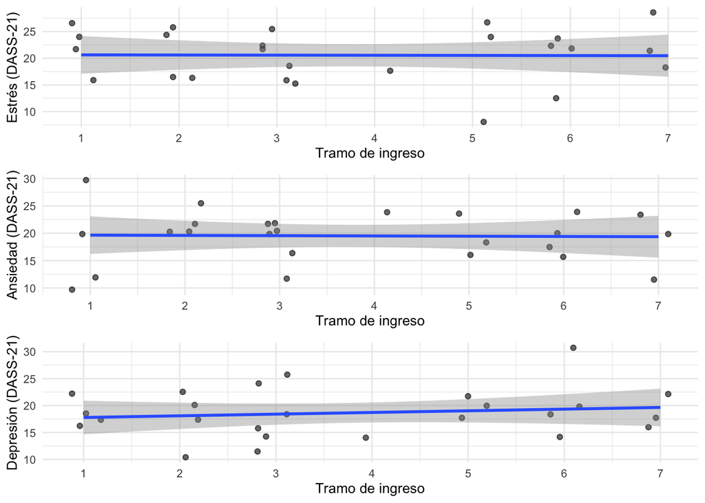

# Resultados

AIM no fue un predictor significativo del estrés, β = -0.04 (95% CI -0.09, 0.01; p=0.086); tampoco de la ansiedad, β = 0.01 (95% CI -0.04, 0.07; p=0.6); ni de la depresión, β = 0.01 (95% CI -0.04, 0.05; p=0.8).